# Intro to Classifiers

Day 13

## Classification

- Last class we discussed models related to predicting continuous numerical data
  - Test score
  - Stock price
- In some cases, we want to explain or predict binary data (0 or 1)
  - Will it rain today?
  - Will I get a job at Amazon?
  - Will I get into graduate school?
- This is called a **classification model**
  - **Binary Response variable:** we classify (i.e. predict) each case as a “success” (1) or “failure” (0)

## Examples of classification

- Medicine: Use DNA sequence data to determine who will get a disease (or not)
- Filtering: Identify spam emails
- Transportation: Predicting whether people will walk, take the bus, or bike
- Purchasing: determine whether individuals will buy a product based on other variables
- [Recidivism:](http://advances.sciencemag.org/content/4/1/eaao5580.full) Predict which defendents or paroles will commit another violent crime

## Classifiers: more formal definition

- **Framework:** We have a (binary) categorical response \(Y\) and \(p\) explanatory variables \(X_1, X_2, ..., X_p\) that may (or may not) be related to \(Y\).
- **Classifier:** A classifier is a model or algorithm that assigns (predicts) a response to cases based on their explanatory variable values.
- **Prediction vs. forecasting:**
  - prediction (or classifying) a categorical response means assigning an outcome (e.g. default/no default)
  - forecasting a categorical response means assigning a probability \(\pi\) of an outcome (e.g an 80% chance of default)
  - most classifiers can do both prediction and forecasting

## Evaluating classifiers: confusion matrix

- Let’s assume we have a binary (1=success or 0=failure) response \(Y\)
  - \(n_1\) successes and \(n_0\) failures
- Our model predicts a binary (1=success or 0=failure) response \(\hat{Y}\)
  - \(\hat{n}_1\) successes and \(\hat{n}_0\) failures
- The four possible combinations of truth and model outcomes are summarized in a **confusion matrix**:

| data/model | Predict: failure (\(\hat{Y}=0\)) | Predict: success (\(\hat{Y}=1\)) | total |
| --- | --- | --- | --- |
| Truth: failure (\(Y=0\)) | true negative (TN) | false positive (FP) | \(n_0\) |
| Truth: success (\(Y=1\)) | false negative (FN) | true positive (TP) | \(n_1\) |
| total | \(\hat{n}_0\) | \(\hat{n}_1\) | \(n\) |

## Evaluating classifiers: confusion matrix

- Sometimes we have to rely on predictions without really knowing the truth
- Depending on the situation, we may weight FP and FN differently
- If we are predicting whether a person is guilty (\(Y=1\)), is a FP or FN worse?
- IF we are predicting whether somebody has COVID (\(Y=1\)), is a FP or FN worse?

## Loan defaults

A loan will default (“success”) if the criteria below is met:

- *Credit amount is greater than 3,000 DM. (close to the mean)*

```r
> loans <- read_csv("https://raw.githubusercontent.com/mgelman/data/master/CreditData.csv")
> loans <- loans %>%
+   mutate(prediction = ifelse(Credit.amount > 3000 , "BadLoan", "GoodLoan") )
> (conf.mat <- with(loans,table(Good.Loan, prediction)))
          prediction
Good.Loan  BadLoan GoodLoan
  BadLoan      134      166
  GoodLoan     246      454
```

So TP = 134, FP = 246, FN = 166, TN = 454

## Evaluating classification models

- In shaded region: TP = 134 red points and FP = 246 blue points

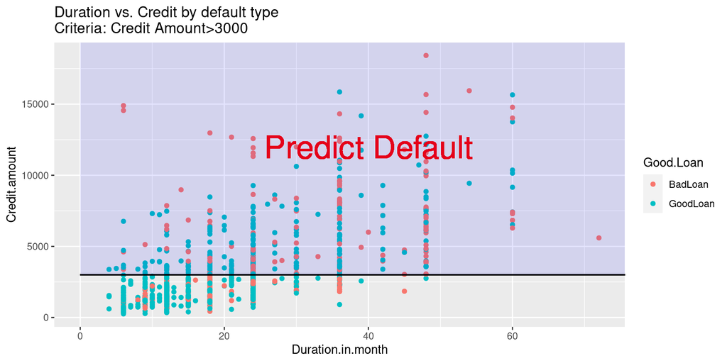

## Evaluating classification models: Accuracy

- **Accuracy**: proportion of data classified correctly (how often is the model correct?) \[\dfrac{TP + TN}{n}\]

```r
> conf.mat
          prediction
Good.Loan  BadLoan GoodLoan
  BadLoan      134      166
  GoodLoan     246      454
> (134+454)/1000
[1] 0.588
```

- Loans model has an accuracy of 58.8%
- Of all cases, 58.8% are correctly predicted using our prediction criteria

## Evaluating classification models: Accuracy

- Can use `prop.table` with two-way table and sum diagonal entries:

```r
> prop.table(conf.mat)
          prediction
Good.Loan  BadLoan GoodLoan
  BadLoan    0.134    0.166
  GoodLoan   0.246    0.454
> sum(diag(prop.table(conf.mat)))
[1] 0.588
```

- or `dplyr` if predicted and actual responses are coded the same:

```r
> loans %>% summarize(accuracy = mean(Good.Loan == prediction))
# A tibble: 1 × 1
  accuracy
     <dbl>
1    0.588
```

## Evaluating classification models

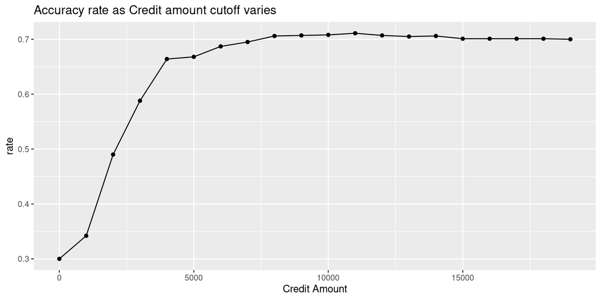

## Evaluating classification models: Precision

- **Precision**: proportion of predicted successes that are actually successes \[\dfrac{TP}{\hat{n}_1}\]
- how often is a positive classification correct?
- assessing “confirmation”

```r
> conf.mat
          prediction
Good.Loan  BadLoan GoodLoan
  BadLoan      134      166
  GoodLoan     246      454
> 134/(134+246)
[1] 0.3526316
```

- Of all loans predicted to default, 35.3% actually did default

## Evaluating classification models: Precision

```r
> prop.table(conf.mat,2)
          prediction
Good.Loan    BadLoan  GoodLoan
  BadLoan  0.3526316 0.2677419
  GoodLoan 0.6473684 0.7322581
> loans %>% summarize(precision = sum(Good.Loan == "BadLoan" &
+                      prediction == "BadLoan")/sum(prediction == "BadLoan"))
# A tibble: 1 × 1
  precision
      <dbl>
1     0.353
> loans %>% filter(prediction == "BadLoan") %>%
+   summarize(precision = sum(Good.Loan == "BadLoan")/n())
# A tibble: 1 × 1
  precision
      <dbl>
1     0.353
```

## Evaluating classification models

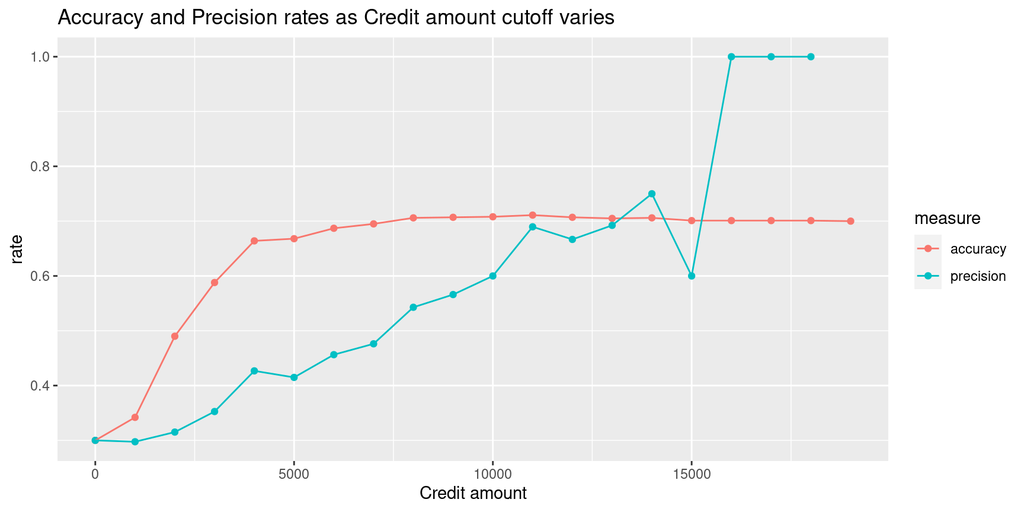

## Evaluating classification models: Recall

- **Recall/sensitivity**: proportion of true successes that are predicted successes \[\dfrac{TP}{n_1}\]
- how often can we correctly identify a success?
- measuring effectiveness

```r
> conf.mat
          prediction
Good.Loan  BadLoan GoodLoan
  BadLoan      134      166
  GoodLoan     246      454
> 134/(134+166)
[1] 0.4466667
```

- Of all loans that defaulted, 44.7% were correctly predicted to default

## Evaluating classification models: Recall

```r
> prop.table(conf.mat,1)
          prediction
Good.Loan    BadLoan  GoodLoan
  BadLoan  0.4466667 0.5533333
  GoodLoan 0.3514286 0.6485714
> loans %>% summarize(recall = sum(Good.Loan == "BadLoan" &
+                      prediction == "BadLoan")/sum(Good.Loan == "BadLoan"))
# A tibble: 1 × 1
  recall
   <dbl>
1  0.447
> loans %>% filter(Good.Loan == "BadLoan") %>%
+   summarize(recall = sum(prediction == "BadLoan")/n())
# A tibble: 1 × 1
  recall
   <dbl>
1  0.447
```

## Evaluating classification models

How do you think `recall` will change as we increase the credit limit cutoff for a `Bad Loan`?

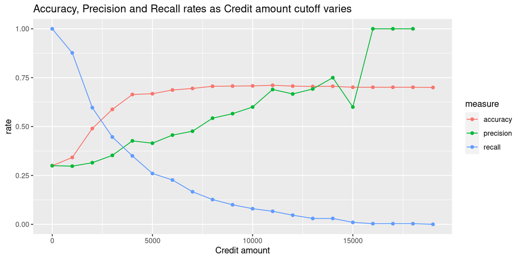

## Evaluating classification models

- Why do we need so many evaluation metrics?

```r
> table(loans$Good.Loan)

 BadLoan GoodLoan
     300      700
```

- In the raw data, 70% of the loans are good
- A model that predicts all loans are good (no loans are bad) will have 70% accuracy
  - Is this a good model?
- Intuitively we know that it’s not a great model. `recall` reminds us that we are doing a horrible job in predicting bad loans that are actually bad
- We would like a model that performs well on all metrics (not always possible as there are trade-offs)

## Summary

- **Classification model**: Explain or predict binary data (0 or 1)
- Evaluating classification models
  - **Accuracy**: Proportion of data classified correctly
  - **Precision**: Of the predicted successes, how many are actual successes?
  - **Recall/Sensitivity**: Of the actual successes, how many did correctly predict?
- Some algorithms can be misleading if the data is heavily skewed towards “success” or “failure”
  - A simple “algorithm” that predicts all observations = success will lead to high `accuracy`